# Project_NYC_FILE_2022

## DESCRIPTION

You've been asked to perform data analysis of service request (311) calls from New York City. You've also been asked to utilize data wrangling techniques to understand the pattern in the data and visualize the major types of complaints.

Note: Download 311-service-requests-nyc.zip file using the link given in the Customer Service Requests Analysis project problem statement and extract the dataset 311_Service_Requests_from_2010_to_Present.csv file

Perform the following steps:

1. Understand the dataset:
   1. Identify the shape of the dataset
   2. Identify variables with null values
2. Perform basic data exploratory analysis:
   1. Utilize missing value treatment
   2. Analyze the date column and remove the entries if it has an incorrect timeline
   3. Draw a frequency plot for city-wise complaints
   4. Draw scatter and hexbin plots for complaint concentration across Brooklyn
3. Find major types of complaints:
   1. Plot a bar graph of count vs. complaint types
   2. Find the top 10 types of complaints
   3. Display the types of complaints in each city in a separate dataset
4. Visualize the major types of complaints in each city
5. Check if the average response time across various types of complaints
6. Identify significant variables by performing a statistical analysis using p-values and chi-square values (Optional)

```python
import pandas as pd
import numpy as np
import warnings
warnings.filterwarnings(action = 'ignore')
import matplotlib.pyplot as plt
import seaborn as sns
%matplotlib inline
import matplotlib as mpl
mpl.rcParams["font.weight"] = "bold"
mpl.rcParams["text.color"] = "red"
mpl.rcParams["font.size"] = 15
mpl.rcParams["font.family"] = "fantasy"
```

```python
df = pd.read_csv(r"C:\Program Files\Common Files\NYC_311_Service_Requests_from_2010_to_Present_Project.csv")
```

```python
df
```

|  | Unique Key | Created Date | Closed Date | Agency | Agency Name | Complaint Type | Descriptor | Location Type | Incident Zip | Incident Address | ... | School Region | School Code | School Phone Number | School Address | School City | School State | School Zip | Latitude | Longitude | Location |
| --- | --- | --- | --- | --- | --- | --- | --- | --- | --- | --- | --- | --- | --- | --- | --- | --- | --- | --- | --- | --- | --- |
| 0 | 32310363 | 12/31/2015 23:59 | 1/1/2016 0:55 | NYPD | New York City Police Department | Noise - Street/Sidewalk | Loud Music/Party | Street/Sidewalk | 10034.0 | 71 VERMILYEA AVENUE | ... | Unspecified | Unspecified | Unspecified | Unspecified | Unspecified | Unspecified | Unspecified | 40.865682 | -73.923501 | (40.86568153633767, -73.92350095571744) |
| 1 | 32309934 | 12/31/2015 23:59 | 1/1/2016 1:26 | NYPD | New York City Police Department | Blocked Driveway | No Access | Street/Sidewalk | 11105.0 | 27-07 23 AVENUE | ... | Unspecified | Unspecified | Unspecified | Unspecified | Unspecified | Unspecified | Unspecified | 40.775945 | -73.915094 | (40.775945312321085, -73.91509393898605) |
| 2 | 32309159 | 12/31/2015 23:59 | 1/1/2016 4:51 | NYPD | New York City Police Department | Blocked Driveway | No Access | Street/Sidewalk | 10458.0 | 2897 VALENTINE AVENUE | ... | Unspecified | Unspecified | Unspecified | Unspecified | Unspecified | Unspecified | Unspecified | 40.870325 | -73.888525 | (40.870324522111424, -73.88852464418646) |
| 3 | 32305098 | 12/31/2015 23:57 | 1/1/2016 7:43 | NYPD | New York City Police Department | Illegal Parking | Commercial Overnight Parking | Street/Sidewalk | 10461.0 | 2940 BAISLEY AVENUE | ... | Unspecified | Unspecified | Unspecified | Unspecified | Unspecified | Unspecified | Unspecified | 40.835994 | -73.828379 | (40.83599404683083, -73.82837939584206) |
| 4 | 32306529 | 12/31/2015 23:56 | 1/1/2016 3:24 | NYPD | New York City Police Department | Illegal Parking | Blocked Sidewalk | Street/Sidewalk | 11373.0 | 87-14 57 ROAD | ... | Unspecified | Unspecified | Unspecified | Unspecified | Unspecified | Unspecified | Unspecified | 40.733060 | -73.874170 | (40.733059618956815, -73.87416975810375) |
| ... | ... | ... | ... | ... | ... | ... | ... | ... | ... | ... | ... | ... | ... | ... | ... | ... | ... | ... | ... | ... | ... |
| 364553 | 29609918 | 1/1/2015 0:04 | 1/1/2015 10:22 | NYPD | New York City Police Department | Illegal Parking | Blocked Hydrant | Street/Sidewalk | 11421.0 | 84-25 85 ROAD | ... | Unspecified | Unspecified | Unspecified | Unspecified | Unspecified | Unspecified | Unspecified | 40.695145 | -73.860949 | (40.69514470265117, -73.86094888534394) |
| 364554 | 29608392 | 1/1/2015 0:04 | 1/1/2015 2:25 | NYPD | New York City Police Department | Noise - Vehicle | Car/Truck Horn | Street/Sidewalk | 10468.0 | 2555 SEDGWICK AVENUE | ... | Unspecified | Unspecified | Unspecified | Unspecified | Unspecified | Unspecified | Unspecified | 40.867830 | -73.907178 | (40.86782963689454, -73.90717786644662) |
| 364555 | 29607589 | 1/1/2015 0:01 | 1/1/2015 0:20 | NYPD | New York City Police Department | Noise - Street/Sidewalk | Loud Music/Party | Street/Sidewalk | 10031.0 | 508 WEST 139 STREET | ... | Unspecified | Unspecified | Unspecified | Unspecified | Unspecified | Unspecified | Unspecified | 40.821647 | -73.950873 | (40.821646626438095, -73.95087342885292) |
| 364556 | 29610889 | 1/1/2015 0:01 | 1/1/2015 2:42 | NYPD | New York City Police Department | Blocked Driveway | No Access | Street/Sidewalk | 10466.0 | 931 EAST 226 STREET | ... | Unspecified | Unspecified | Unspecified | Unspecified | Unspecified | Unspecified | Unspecified | 40.886361 | -73.853290 | (40.88636077906953, -73.85329048666742) |
| 364557 | 29611816 | 1/1/2015 0:00 | 1/1/2015 2:47 | NYPD | New York City Police Department | Blocked Driveway | No Access | Street/Sidewalk | 11420.0 | 123-19 135 STREET | ... | Unspecified | Unspecified | Unspecified | Unspecified | Unspecified | Unspecified | Unspecified | 40.674212 | -73.803585 | (40.674211762243935, -73.80358548685278) |

364558 rows × 41 columns

```python
df.shape
```

```
(364558, 41)
```

```python
df.isnull()
```

|  | Unique Key | Created Date | Closed Date | Agency | Agency Name | Complaint Type | Descriptor | Location Type | Incident Zip | Incident Address | ... | School Region | School Code | School Phone Number | School Address | School City | School State | School Zip | Latitude | Longitude | Location |
| --- | --- | --- | --- | --- | --- | --- | --- | --- | --- | --- | --- | --- | --- | --- | --- | --- | --- | --- | --- | --- | --- |
| 0 | False | False | False | False | False | False | False | False | False | False | ... | False | False | False | False | False | False | False | False | False | False |
| 1 | False | False | False | False | False | False | False | False | False | False | ... | False | False | False | False | False | False | False | False | False | False |
| 2 | False | False | False | False | False | False | False | False | False | False | ... | False | False | False | False | False | False | False | False | False | False |
| 3 | False | False | False | False | False | False | False | False | False | False | ... | False | False | False | False | False | False | False | False | False | False |
| 4 | False | False | False | False | False | False | False | False | False | False | ... | False | False | False | False | False | False | False | False | False | False |
| ... | ... | ... | ... | ... | ... | ... | ... | ... | ... | ... | ... | ... | ... | ... | ... | ... | ... | ... | ... | ... | ... |
| 364553 | False | False | False | False | False | False | False | False | False | False | ... | False | False | False | False | False | False | False | False | False | False |
| 364554 | False | False | False | False | False | False | False | False | False | False | ... | False | False | False | False | False | False | False | False | False | False |
| 364555 | False | False | False | False | False | False | False | False | False | False | ... | False | False | False | False | False | False | False | False | False | False |
| 364556 | False | False | False | False | False | False | False | False | False | False | ... | False | False | False | False | False | False | False | False | False | False |
| 364557 | False | False | False | False | False | False | False | False | False | False | ... | False | False | False | False | False | False | False | False | False | False |

364558 rows × 41 columns

### Removed all the null value columns

```python
df.dropna(axis = 1)
```

|  | Unique Key | Created Date | Agency | Agency Name | Complaint Type | Status | Resolution Description | Community Board | Borough | Park Facility Name | Park Borough | School Name | School Number | School Phone Number | School Address | School City | School State |
| --- | --- | --- | --- | --- | --- | --- | --- | --- | --- | --- | --- | --- | --- | --- | --- | --- | --- |
| 0 | 32310363 | 12/31/2015 23:59 | NYPD | New York City Police Department | Noise - Street/Sidewalk | Closed | The Police Department responded and upon arriv... | 12 MANHATTAN | MANHATTAN | Unspecified | MANHATTAN | Unspecified | Unspecified | Unspecified | Unspecified | Unspecified | Unspecified |
| 1 | 32309934 | 12/31/2015 23:59 | NYPD | New York City Police Department | Blocked Driveway | Closed | The Police Department responded to the complai... | 01 QUEENS | QUEENS | Unspecified | QUEENS | Unspecified | Unspecified | Unspecified | Unspecified | Unspecified | Unspecified |
| 2 | 32309159 | 12/31/2015 23:59 | NYPD | New York City Police Department | Blocked Driveway | Closed | The Police Department responded and upon arriv... | 07 BRONX | BRONX | Unspecified | BRONX | Unspecified | Unspecified | Unspecified | Unspecified | Unspecified | Unspecified |
| 3 | 32305098 | 12/31/2015 23:57 | NYPD | New York City Police Department | Illegal Parking | Closed | The Police Department responded to the complai... | 10 BRONX | BRONX | Unspecified | BRONX | Unspecified | Unspecified | Unspecified | Unspecified | Unspecified | Unspecified |
| 4 | 32306529 | 12/31/2015 23:56 | NYPD | New York City Police Department | Illegal Parking | Closed | The Police Department responded and upon arriv... | 04 QUEENS | QUEENS | Unspecified | QUEENS | Unspecified | Unspecified | Unspecified | Unspecified | Unspecified | Unspecified |
| ... | ... | ... | ... | ... | ... | ... | ... | ... | ... | ... | ... | ... | ... | ... | ... | ... | ... |
| 364553 | 29609918 | 1/1/2015 0:04 | NYPD | New York City Police Department | Illegal Parking | Closed | The Police Department responded to the complai... | 09 QUEENS | QUEENS | Unspecified | QUEENS | Unspecified | Unspecified | Unspecified | Unspecified | Unspecified | Unspecified |
| 364554 | 29608392 | 1/1/2015 0:04 | NYPD | New York City Police Department | Noise - Vehicle | Closed | The Police Department responded to the complai... | 07 BRONX | BRONX | Unspecified | BRONX | Unspecified | Unspecified | Unspecified | Unspecified | Unspecified | Unspecified |
| 364555 | 29607589 | 1/1/2015 0:01 | NYPD | New York City Police Department | Noise - Street/Sidewalk | Closed | The Police Department responded to the complai... | 09 MANHATTAN | MANHATTAN | Unspecified | MANHATTAN | Unspecified | Unspecified | Unspecified | Unspecified | Unspecified | Unspecified |
| 364556 | 29610889 | 1/1/2015 0:01 | NYPD | New York City Police Department | Blocked Driveway | Closed | The Police Department responded and upon arriv... | 12 BRONX | BRONX | Unspecified | BRONX | Unspecified | Unspecified | Unspecified | Unspecified | Unspecified | Unspecified |
| 364557 | 29611816 | 1/1/2015 0:00 | NYPD | New York City Police Department | Blocked Driveway | Closed | The Police Department responded to the complai... | 10 QUEENS | QUEENS | Unspecified | QUEENS | Unspecified | Unspecified | Unspecified | Unspecified | Unspecified | Unspecified |

364558 rows × 17 columns

### Missing Value Treatment

#### Descreptor column

```python
df.Descriptor.isnull().sum()
```

```
6501
```

```python
df.Descriptor[df.Descriptor.isnull()] = "N"
```

```python
df.Descriptor.isnull().sum()
```

```
0
```

### Column names replaced to (' ' to _ )

```python
Ag = "Agency Name"
```

```python
Ag.replace(" ", "_")
```

```
'Agency_Name'
```

```python
df.rename(mapper = lambda x:x.replace(" ","_"), axis = 1, inplace = True)
```

```python
df
```

|  | Unique_Key | Created_Date | Closed_Date | Agency | Agency_Name | Complaint_Type | Descriptor | Location_Type | Incident_Zip | Incident_Address | ... | School_Region | School_Code | School_Phone_Number | School_Address | School_City | School_State | School_Zip | Latitude | Longitude | Location |
| --- | --- | --- | --- | --- | --- | --- | --- | --- | --- | --- | --- | --- | --- | --- | --- | --- | --- | --- | --- | --- | --- |
| 0 | 32310363 | 12/31/2015 23:59 | 1/1/2016 0:55 | NYPD | New York City Police Department | Noise - Street/Sidewalk | Loud Music/Party | Street/Sidewalk | 10034.0 | 71 VERMILYEA AVENUE | ... | Unspecified | Unspecified | Unspecified | Unspecified | Unspecified | Unspecified | Unspecified | 40.865682 | -73.923501 | (40.86568153633767, -73.92350095571744) |
| 1 | 32309934 | 12/31/2015 23:59 | 1/1/2016 1:26 | NYPD | New York City Police Department | Blocked Driveway | No Access | Street/Sidewalk | 11105.0 | 27-07 23 AVENUE | ... | Unspecified | Unspecified | Unspecified | Unspecified | Unspecified | Unspecified | Unspecified | 40.775945 | -73.915094 | (40.775945312321085, -73.91509393898605) |
| 2 | 32309159 | 12/31/2015 23:59 | 1/1/2016 4:51 | NYPD | New York City Police Department | Blocked Driveway | No Access | Street/Sidewalk | 10458.0 | 2897 VALENTINE AVENUE | ... | Unspecified | Unspecified | Unspecified | Unspecified | Unspecified | Unspecified | Unspecified | 40.870325 | -73.888525 | (40.870324522111424, -73.88852464418646) |
| 3 | 32305098 | 12/31/2015 23:57 | 1/1/2016 7:43 | NYPD | New York City Police Department | Illegal Parking | Commercial Overnight Parking | Street/Sidewalk | 10461.0 | 2940 BAISLEY AVENUE | ... | Unspecified | Unspecified | Unspecified | Unspecified | Unspecified | Unspecified | Unspecified | 40.835994 | -73.828379 | (40.83599404683083, -73.82837939584206) |
| 4 | 32306529 | 12/31/2015 23:56 | 1/1/2016 3:24 | NYPD | New York City Police Department | Illegal Parking | Blocked Sidewalk | Street/Sidewalk | 11373.0 | 87-14 57 ROAD | ... | Unspecified | Unspecified | Unspecified | Unspecified | Unspecified | Unspecified | Unspecified | 40.733060 | -73.874170 | (40.733059618956815, -73.87416975810375) |
| ... | ... | ... | ... | ... | ... | ... | ... | ... | ... | ... | ... | ... | ... | ... | ... | ... | ... | ... | ... | ... | ... |
| 364553 | 29609918 | 1/1/2015 0:04 | 1/1/2015 10:22 | NYPD | New York City Police Department | Illegal Parking | Blocked Hydrant | Street/Sidewalk | 11421.0 | 84-25 85 ROAD | ... | Unspecified | Unspecified | Unspecified | Unspecified | Unspecified | Unspecified | Unspecified | 40.695145 | -73.860949 | (40.69514470265117, -73.86094888534394) |
| 364554 | 29608392 | 1/1/2015 0:04 | 1/1/2015 2:25 | NYPD | New York City Police Department | Noise - Vehicle | Car/Truck Horn | Street/Sidewalk | 10468.0 | 2555 SEDGWICK AVENUE | ... | Unspecified | Unspecified | Unspecified | Unspecified | Unspecified | Unspecified | Unspecified | 40.867830 | -73.907178 | (40.86782963689454, -73.90717786644662) |
| 364555 | 29607589 | 1/1/2015 0:01 | 1/1/2015 0:20 | NYPD | New York City Police Department | Noise - Street/Sidewalk | Loud Music/Party | Street/Sidewalk | 10031.0 | 508 WEST 139 STREET | ... | Unspecified | Unspecified | Unspecified | Unspecified | Unspecified | Unspecified | Unspecified | 40.821647 | -73.950873 | (40.821646626438095, -73.95087342885292) |
| 364556 | 29610889 | 1/1/2015 0:01 | 1/1/2015 2:42 | NYPD | New York City Police Department | Blocked Driveway | No Access | Street/Sidewalk | 10466.0 | 931 EAST 226 STREET | ... | Unspecified | Unspecified | Unspecified | Unspecified | Unspecified | Unspecified | Unspecified | 40.886361 | -73.853290 | (40.88636077906953, -73.85329048666742) |
| 364557 | 29611816 | 1/1/2015 0:00 | 1/1/2015 2:47 | NYPD | New York City Police Department | Blocked Driveway | No Access | Street/Sidewalk | 11420.0 | 123-19 135 STREET | ... | Unspecified | Unspecified | Unspecified | Unspecified | Unspecified | Unspecified | Unspecified | 40.674212 | -73.803585 | (40.674211762243935, -73.80358548685278) |

364558 rows × 41 columns

#### City Column

```python
df.City.isnull().sum()
```

```
2997
```

```python
df.City[df.City.isnull()] = "N"
```

```python
df.City.isnull().sum()
```

```
0
```

#### Incident Zip column

```python
df.Incident_Zip.isnull().sum()
```

```
2998
```

```python
df.Incident_Zip[df.Incident_Zip.isnull()] = "N"
```

```python
df.Incident_Zip.isnull().sum()
```

```
0
```

#### Incident Adress column

```python
df.Incident_Address.isnull().sum()
```

```
51699
```

```python
df.Incident_Address[df.Incident_Address.isnull()] = "N"
```

```python
df.Incident_Address.isnull().sum()
```

```
0
```

#### Location Type column

```python
df.Location_Type.isnull().sum()
```

```
133
```

```python
df.Location_Type[df.Location_Type.isnull()] = "N"
```

```python
df.Location_Type.isnull().sum()
```

```
0
```

#### Numerical column Latitude and longitude

```python
mean_lat = df.Latitude.mean()
```

```python
df.Latitude.isnull().sum()
```

```
4030
```

```python
df.loc[df.Latitude.isnull(), "Latitude"] = mean_lat
```

```python
df.Latitude.isnull().sum()
```

```
0
```

```python
mean_lon = df.Longitude.mean()
```

```python
df.Longitude.isnull().sum()
```

```
4030
```

```python
df.loc[df.Longitude.isnull(), "Longitude"] = mean_lon
```

```python
df.Longitude.isnull().sum()
```

```
0
```

### Analysis of datetime column

```python
df.Created_Date
```

```
0         12/31/2015 23:59
1         12/31/2015 23:59
2         12/31/2015 23:59
3         12/31/2015 23:57
4         12/31/2015 23:56
                ...
364553       1/1/2015 0:04
364554       1/1/2015 0:04
364555       1/1/2015 0:01
364556       1/1/2015 0:01
364557       1/1/2015 0:00
Name: Created_Date, Length: 364558, dtype: object
```

```python
pd.to_datetime(df["Created_Date"], format = "%m/%d/%Y %H:%M", errors = "coerce")
```

```
0        2015-12-31 23:59:00
1        2015-12-31 23:59:00
2        2015-12-31 23:59:00
3        2015-12-31 23:57:00
4        2015-12-31 23:56:00
                 ...
364553   2015-01-01 00:04:00
364554   2015-01-01 00:04:00
364555   2015-01-01 00:01:00
364556   2015-01-01 00:01:00
364557   2015-01-01 00:00:00
Name: Created_Date, Length: 364558, dtype: datetime64[ns]
```

```python
df.Created_Date.isnull().sum()
```

```
0
```

## Frequency plot for City wise complaints

```python
print(plt.colormaps())
```

[output not shown]

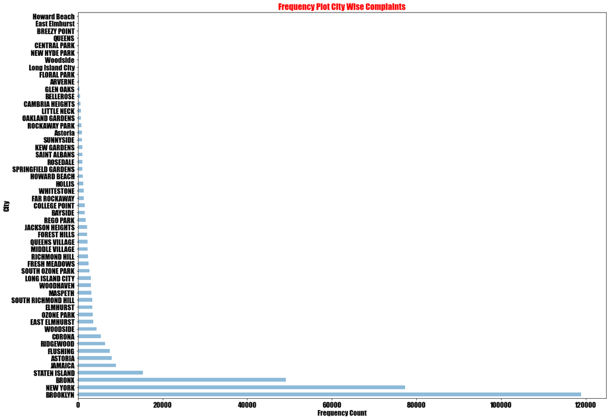

```python
plt.figure(figsize = (20,5))
plt.title("Frequency Plot City Wise Complaints")
plt.xlabel("Frequency Count")
plt.ylabel("City")
df["City"].value_counts().plot(kind = "barh" , alpha = .5, figsize = (20,15))
```

```python
ct = "Complaint_Type"
```

```python
ct.replace("_"," ")
```

```
'Complaint Type'
```

```python
df.rename(mapper = lambda x:x.replace("_"," "), axis = 1 , inplace = True)
```

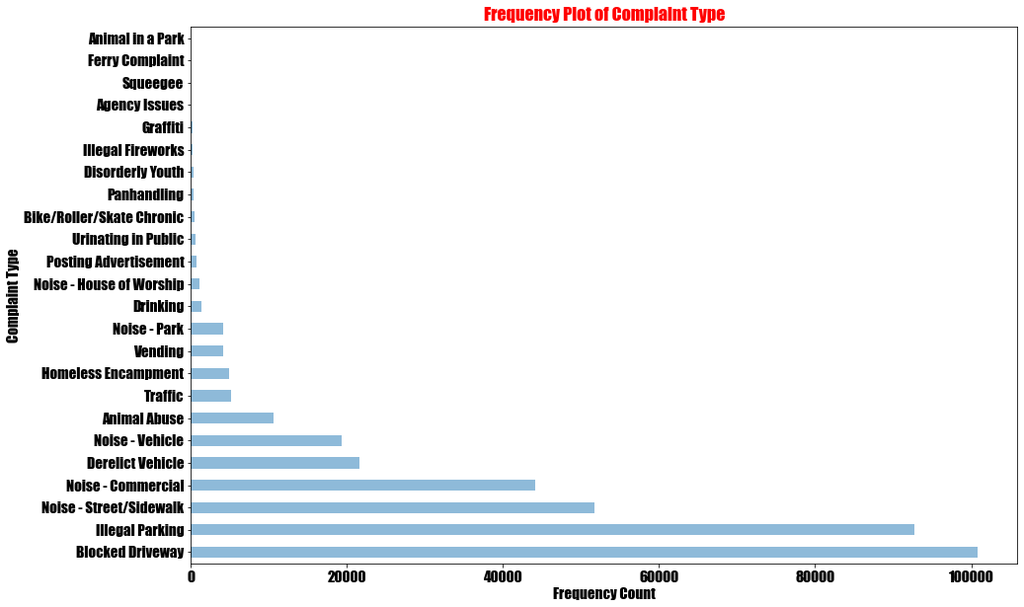

```python
plt.figure(figsize = (20,5))
plt.title("Frequency Plot of Complaint Type")
plt.xlabel("Frequency Count")
plt.ylabel("Complaint Type")
df["Complaint Type"].value_counts().plot(kind = "barh" , alpha = .5, figsize = (15,10))
```

```python
df["Complaint Type"].value_counts()
```

```
Blocked Driveway             100881
Illegal Parking               92679
Noise - Street/Sidewalk       51692
Noise - Commercial            44109
Derelict Vehicle              21661
Noise - Vehicle               19352
Animal Abuse                  10541
Traffic                        5198
Homeless Encampment            4879
Vending                        4192
Noise - Park                   4109
Drinking                       1409
Noise - House of Worship       1070
Posting Advertisement           681
Urinating in Public             641
Bike/Roller/Skate Chronic       478
Panhandling                     327
Disorderly Youth                315
Illegal Fireworks               172
Graffiti                        157
Agency Issues                     8
Squeegee                          4
Ferry Complaint                   2
Animal in a Park                  1
Name: Complaint Type, dtype: int64
```

### Scatter Plot For Complaint Concentration Across Brooklyn

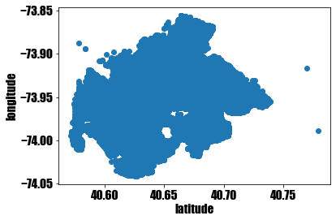

```python
plt.xlabel("latitude")
plt.ylabel("longitude")
broooklyn = df.loc[df.City == "BROOKLYN", ['Latitude', 'Longitude']]
plt.scatter(broooklyn.Latitude, broooklyn.Longitude)
```

### Hexbin Plot For Complaint Concentration Across Brooklyn

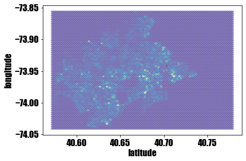

```python
plt.xlabel("latitude")
plt.ylabel("longitude")
brooklyn = df.loc[df.City == "BROOKLYN", ['Latitude', 'Longitude']]
plt.hexbin(brooklyn.Latitude, brooklyn.Longitude, alpha = .5 , cmap = "Spectral_r")
```

### Bar Graph Count vs Complaint Type

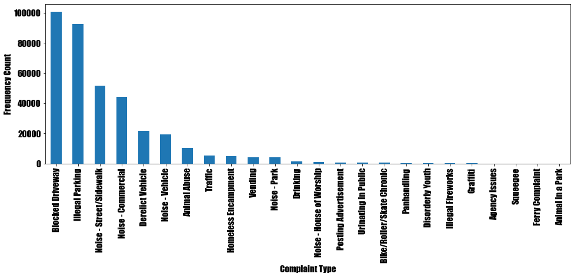

```python
plt.figure(figsize = (16,5))
plt.xlabel("Complaint Type")
plt.ylabel("Frequency Count")
df["Complaint Type"].value_counts().plot(kind = "bar")
```

### Major 10 Types of Complaint

```python
df["Complaint Type"].value_counts().sort_values(ascending = False)[0:10:1]
```

```
Blocked Driveway           100881
Illegal Parking             92679
Noise - Street/Sidewalk     51692
Noise - Commercial          44109
Derelict Vehicle            21661
Noise - Vehicle             19352
Animal Abuse                10541
Traffic                      5198
Homeless Encampment          4879
Vending                      4192
Name: Complaint Type, dtype: int64
```

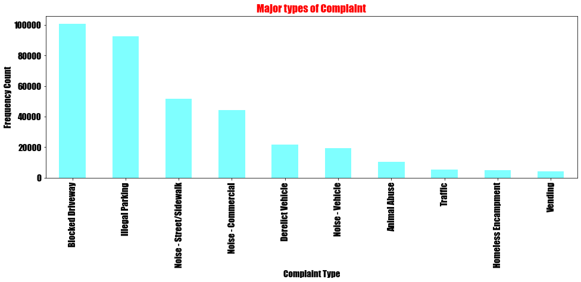

```python
plt.figure(figsize = (16,5))
plt.title("Major types of Complaint")
plt.xlabel("Complaint Type")
plt.ylabel("Frequency Count")
df["Complaint Type"].value_counts().nlargest(10).plot(kind = "bar", cmap = "cool", alpha = .5)
```

### Display The Types Of Complaints In Each City

```python
df.groupby(["Complaint Type", "City"]).size()
```

```
Complaint Type  City
Animal Abuse    ARVERNE          1
                ASTORIA          1
                BAYSIDE          1
                BELLEROSE        1
                BREEZY POINT     1
                                ..
Vending         STATEN ISLAND    1
                SUNNYSIDE        1
                WHITESTONE       1
                WOODHAVEN        1
                WOODSIDE         1
Length: 777, dtype: int64
```